# Chapter3_Practice

Zhang Chen

7/17/2018

# Easy

## 4E1

the first line

## 4E2

two

## 4E4

the second line

## 4E5

three

# Medium

## 4M1

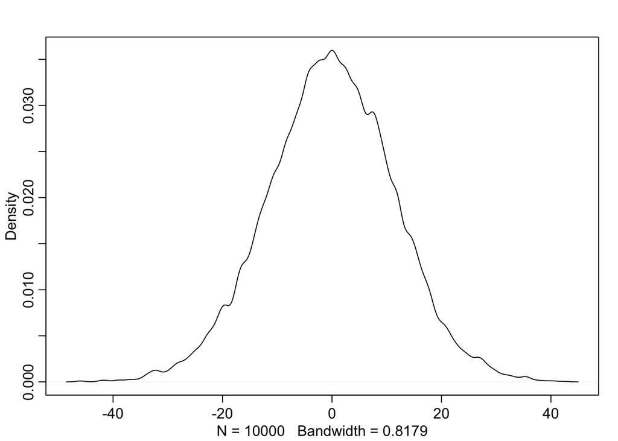

```r
library(rethinking)
sim.mu <- rnorm(1e4, mean=0, sd=10)
sim.sigma <- runif(1e4, min=0, max=10)
sim.height <- rnorm(1e4, mean=sim.mu, sd=sim.sigma)

dens(sim.height)
```

## 4M2

```r
flist <- alist(
  height ~ dnorm(mu, sigma),
  mu ~ dnorm(0, 10),
  sigma ~ dunif(0, 10)
)
```

## 4M3

height[i] ~ Normal(mu[i], sigma)

mu[i] <- a + b*x[i]

a ~ Normal(0, 50)

b ~ Uniform(0, 10)

sigma ~ Uniform(0, 50)

## 4M4

height ~ Normal(average height, sigma)

average height <- a + b*year

a ~ Normal(180, 100)

b ~ Normal(0, 10)

sigma ~ dunif(0, 100)

## 4M5

Knowing that the average height of the students in the first year was 120 cm, there is no uncertainty in the parameter a anymore. So the linear model will become average height <- 120 + b*year.

Knowing that every student got taller each year, the parameter b has to be positive. A half-Normal distribution on b can be used as the prior.

## 4M6

With this new information, the prior on sigma will become an uniform distribution from 0 to 64.

# Hard

## 4H1

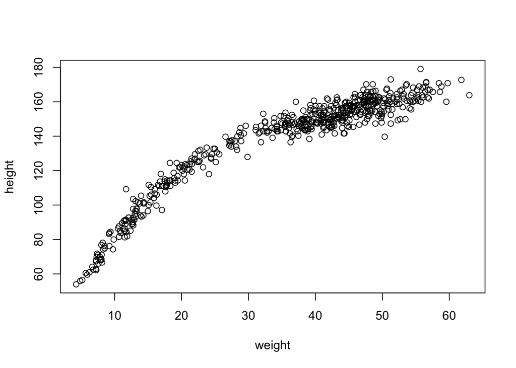

```r
data("Howell1")
d <- Howell1

# plot raw data
plot(height ~ weight, data=d)
```

```r
# fit a polynomial regression
d$weight.s  <- scale(d$weight)
d$weight.s2 <- d$weight.s^2

m.4h1 <- map(
  alist(
    height ~ dnorm(mu, sigma),
    mu <- a+b1*weight.s+b2*weight.s2,
    a ~ dnorm(178, 100),
    b1 ~ dnorm(0, 20),
    b2 ~ dnorm(0, 20),
    sigma ~ dunif(0, 50)
  ),
  data = d)

precis(m.4h1, corr=TRUE)
```

```
##         Mean StdDev   5.5%  94.5%     a    b1    b2 sigma
## a     146.66   0.37 146.06 147.26  1.00 -0.39 -0.75     0
## b1     21.41   0.29  20.95  21.87 -0.39  1.00  0.53     0
## b2     -8.41   0.28  -8.86  -7.96 -0.75  0.53  1.00     0
## sigma   5.75   0.17   5.47   6.03  0.00  0.00  0.00     1
```

```r
# plot results
weight.seq <- seq(from=min(d$weight.s), to=max(d$weight.s), length.out=40)
pred_data  <- list(weight.s=weight.seq, weight.s2=weight.seq^2)

mu <- link(m.4h1, data=pred_data)
```

```
## [ 100 / 1000 ]
[ 200 / 1000 ]
[ 300 / 1000 ]
[ 400 / 1000 ]
[ 500 / 1000 ]
[ 600 / 1000 ]
[ 700 / 1000 ]
[ 800 / 1000 ]
[ 900 / 1000 ]
[ 1000 / 1000 ]
```

```r
mu.mean <- apply(mu, 2, mean)
mu.PI   <- apply(mu, 2, PI, prob=0.89)

sim.heights <- sim(m.4h1, data=pred_data)
```

```
## [ 100 / 1000 ]
[ 200 / 1000 ]
[ 300 / 1000 ]
[ 400 / 1000 ]
[ 500 / 1000 ]
[ 600 / 1000 ]
[ 700 / 1000 ]
[ 800 / 1000 ]
[ 900 / 1000 ]
[ 1000 / 1000 ]
```

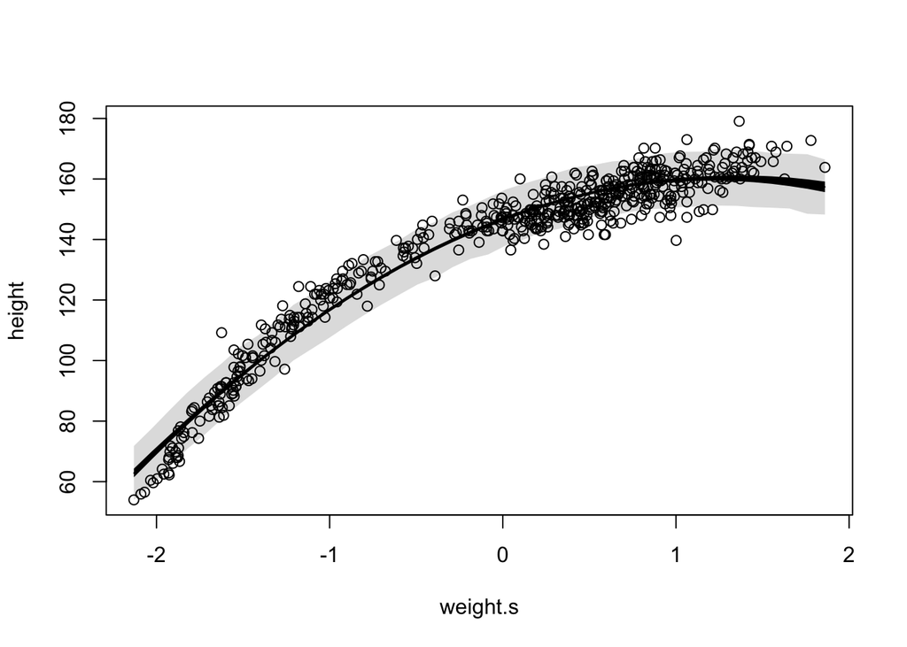

```r
heights.PI  <- apply(sim.heights, 2, PI, prob=0.89)

plot(height ~ weight.s, data=d)
lines(weight.seq, mu.mean)
shade(mu.PI, weight.seq, col="black")
shade(heights.PI, weight.seq)
```

```r
# make predictions for the five individuals with missing height
weight.obs <- c(46.95, 43.72, 64.78, 32.59, 54.63)
weight.obs <- (weight.obs-mean(d$weight))/sd(d$weight)

pred_data <- list(weight.s=weight.obs, weight.s2=weight.obs^2)
heights.pred <- sim(m.4h1, data=pred_data)
```

```
## [ 100 / 1000 ]
[ 200 / 1000 ]
[ 300 / 1000 ]
[ 400 / 1000 ]
[ 500 / 1000 ]
[ 600 / 1000 ]
[ 700 / 1000 ]
[ 800 / 1000 ]
[ 900 / 1000 ]
[ 1000 / 1000 ]
```

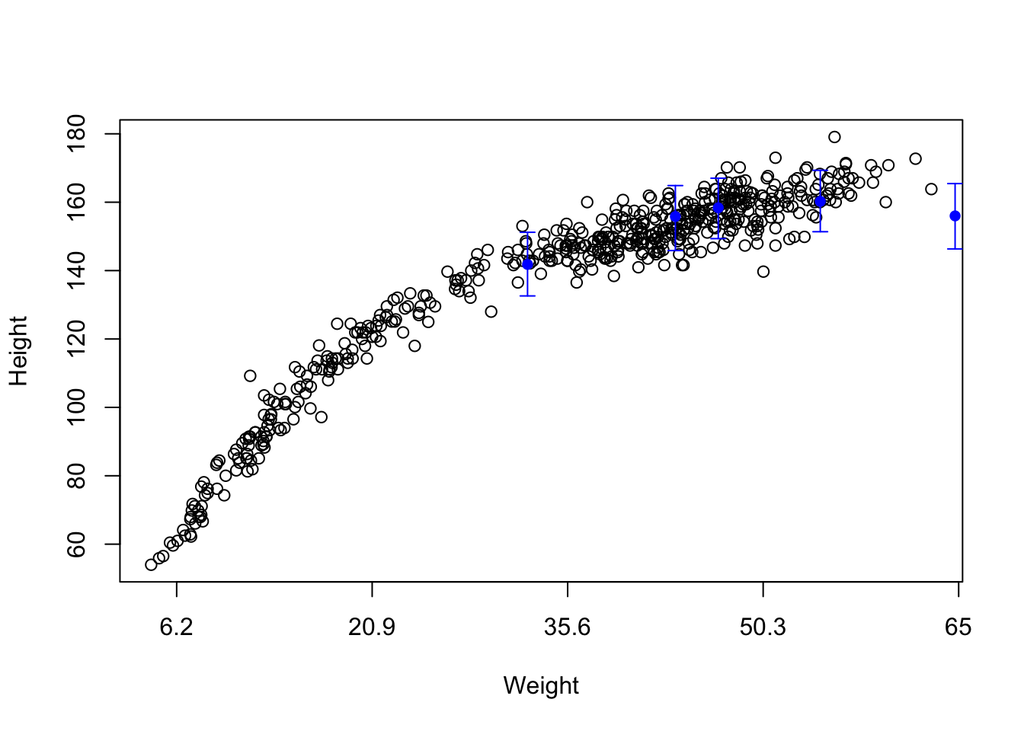

```r
heights.mean <- apply(heights.pred, 2, mean)
heights.PI   <- apply(heights.pred, 2, PI, prob=0.89)

# plot results
plot(height ~ weight.s, data=d, xaxt="n", xlab="Weight", ylab="Height")
at <- c(-2, -1, 0, 1, 2)
labels <- at*sd(d$weight)+mean(d$weight)
axis(side=1, at=at, labels=round(labels, 1))

points(x=weight.obs, y=heights.mean, col="blue", pch=16)
arrows(weight.obs, heights.PI[1,], weight.obs, heights.PI[2,],
       length=0.05, angle=90, code=3, col="blue")
```

## 4H2

```r
d2 <- d[d$age < 18, ]

m.4h2 <- map(
  alist(
    height ~ dnorm(mu, sigma),
    mu <- a + b*weight,
    a ~ dnorm(100, 100),
    b ~ dnorm(0, 20),
    sigma ~ dunif(0, 50)
  ),
  data=d2)

precis(m.4h2, corr=TRUE)
```

```
##        Mean StdDev  5.5% 94.5%    a    b sigma
## a     58.24   1.40 56.01 60.47  1.0 -0.9     0
## b      2.72   0.07  2.61  2.83 -0.9  1.0     0
## sigma  8.44   0.43  7.75  9.13  0.0  0.0     1
```

```r
# Plot results
weight.seq <- seq(from=min(d2$weight), to=max(d2$weight), length.out=40)
pred_data  <- list(weight=weight.seq)

mu <- link(m.4h2, data=pred_data)
```

```
## [ 100 / 1000 ]
[ 200 / 1000 ]
[ 300 / 1000 ]
[ 400 / 1000 ]
[ 500 / 1000 ]
[ 600 / 1000 ]
[ 700 / 1000 ]
[ 800 / 1000 ]
[ 900 / 1000 ]
[ 1000 / 1000 ]
```

```r
mu.mean <- apply(mu, 2, mean)
mu.PI   <- apply(mu, 2, PI, prob=0.89)

sim.heights <- sim(m.4h2, data=pred_data)
```

```
## [ 100 / 1000 ]
[ 200 / 1000 ]
[ 300 / 1000 ]
[ 400 / 1000 ]
[ 500 / 1000 ]
[ 600 / 1000 ]
[ 700 / 1000 ]
[ 800 / 1000 ]
[ 900 / 1000 ]
[ 1000 / 1000 ]
```

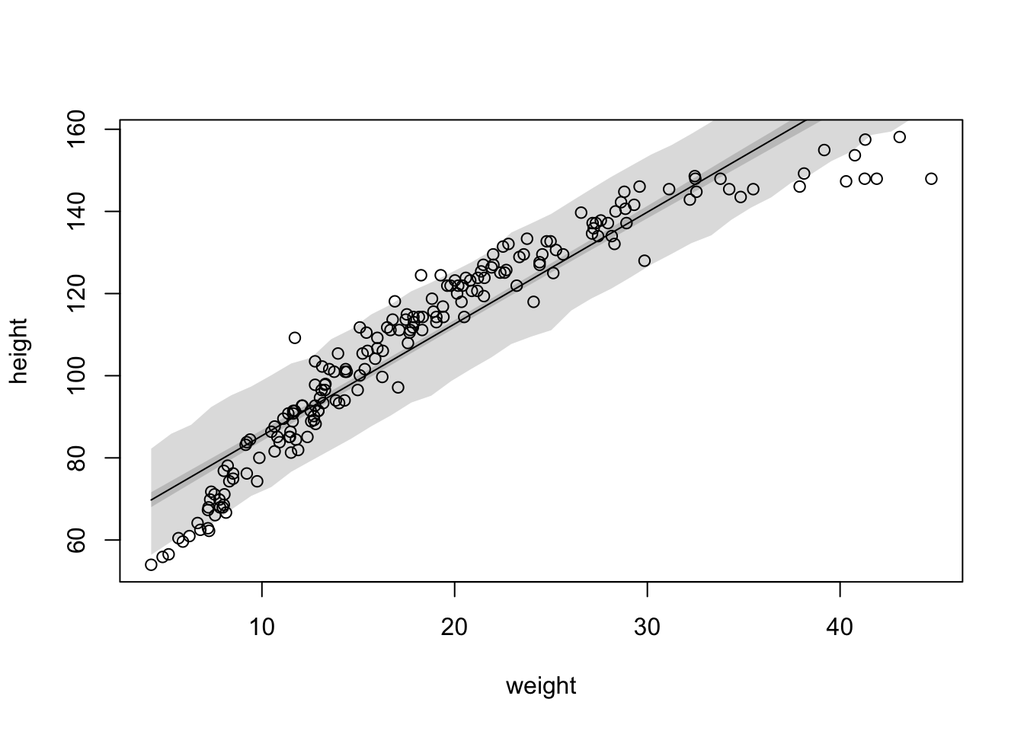

```r
height.PI   <- apply(sim.heights, 2, PI, prob=0.89)

plot(height ~ weight, data=d2)
lines(weight.seq, mu.mean)
shade(mu.PI, weight.seq)
shade(height.PI, weight.seq)
```

The relationship between weight and height does not seem to be linear. The model tends to make predictions that are above observed heights at the two extreme ends of weight; when weight is in the middle range (from 15 till around 30), the predictions of the model are consistently lower than the observed heights.

## 4H3

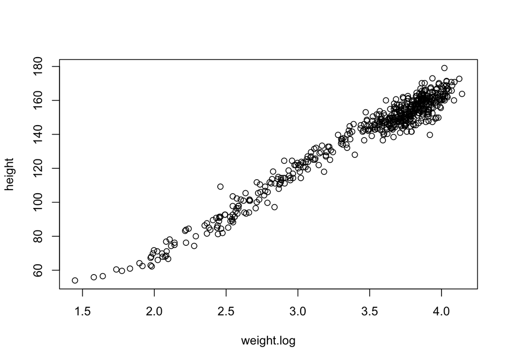

```r
d$weight.log <- log(d$weight)

# plot raw data points
plot(height ~ weight.log, data=d)
```

```r
# fit a linear regression model
m.4h3 <- map(
  alist(
    height ~ dnorm(mu, sigma),
    mu <- a+b*weight.log,
    a ~ dnorm(178, 100),
    b ~ dnorm(0, 100),
    sigma ~ dunif(0, 50)
  ),
  data=d)

precis(m.4h3, corr=TRUE)
```

```
##         Mean StdDev   5.5%  94.5%     a     b sigma
## a     -23.78   1.34 -25.92 -21.65  1.00 -0.99     0
## b      47.08   0.38  46.46  47.69 -0.99  1.00     0
## sigma   5.13   0.16   4.89   5.38  0.00  0.00     1
```

```r
# plot results
weight.seq <- seq(from=min(d$weight), to=max(d$weight),length.out=100)
weight.log.seq <- log(weight.seq)

pred_data <- list(weight.log=weight.log.seq)
mu <- link(m.4h3, data=pred_data)
```

```
## [ 100 / 1000 ]
[ 200 / 1000 ]
[ 300 / 1000 ]
[ 400 / 1000 ]
[ 500 / 1000 ]
[ 600 / 1000 ]
[ 700 / 1000 ]
[ 800 / 1000 ]
[ 900 / 1000 ]
[ 1000 / 1000 ]
```

```r
mu.mean <- apply(mu, 2, mean)
mu.HPDI <- apply(mu, 2, HPDI, prob=0.97)

sim.heights <- sim(m.4h3, data=pred_data)
```

```
## [ 100 / 1000 ]
[ 200 / 1000 ]
[ 300 / 1000 ]
[ 400 / 1000 ]
[ 500 / 1000 ]
[ 600 / 1000 ]
[ 700 / 1000 ]
[ 800 / 1000 ]
[ 900 / 1000 ]
[ 1000 / 1000 ]
```

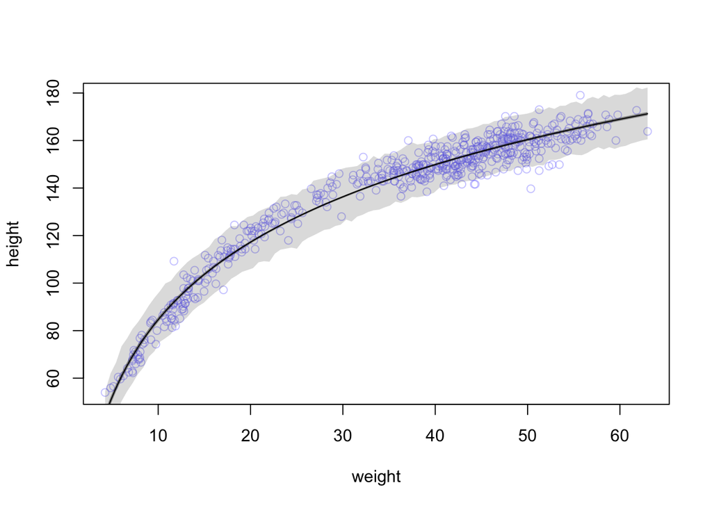

```r
height.HPDI <- apply(sim.heights, 2, HPDI, prob=0.97)

plot(height ~ weight, data=d, col=col.alpha(rangi2, 0.4))
lines(weight.seq, mu.mean)
shade(mu.HPDI, weight.seq, col=col.alpha("black", alpha=0.4))
shade(height.HPDI, weight.seq)
```